# Least_Sandpiper_Code

### Interactive Migration Map of Least Sandpiper *Calidris minutilla*

[figure not shown]

Photo by Adelia Honeywood

I took this photo at Jamaica Bay NWR on August 11, 2024. Juvenile Least Sandpipers migrate later than adults and peak in the first two weeks of August (Miller, 1983; Nebel & Cooper, 2020). These birds are likely juveniles as evidenced by their spiffy, fresh-looking plumage.

Occurrence data on Least Sandpiper (*Calidris minutilla*) was pulled from the [Global Biodiversity Information Facility (GBIF)](https://www.gbif.org/) and is based on human observations of occurrence, not counts, from iNaturalist Research-grade Observations. This data is joined to ecoregions from the [Ecoregions of the World Dataset published by RESOLVE](https://www.resolve.ngo/projects/ecoregions-world).

Miller, E. H. (1983). Habitat and breeding cycle of the Least Sandpiper (Calidris minutilla) on Sable Island, Nova Scotia. Canadian Journal of Zoology, 61(12), 2880–2898. https://doi.org/10.1139/z83-376  
Nebel, S., & Cooper, J. M. (2020). Least Sandpiper (Calidris minutilla), version 1.0. Birds of the World. https://doi.org/10.2173/bow.leasan.01

```python
import time ### time processing steps
import zipfile ### read and extract .zip folders
from getpass import getpass ### handles sensitive inputs like passwords and API tokens
from glob import glob ### function for finding file paths
import requests ### make requests to websites and web APIs

### GBIF packages
import pygbif.occurrences as occ ### get GBIF occurrence data
import pygbif.species as species ### deals with species names

### folder/file management
import os
import pathlib

### tabular data
import pandas as pd

### handle geospatial vector data
import geopandas as gpd

### access prepped gbif data
import earthpy as et


#### for the second notebook
### import libraries for dynamic mapping

### manage crs
import cartopy.crs as ccrs

### customize the dynamic plot
import panel as pn

### make dynamic plot with geodataframe
import hvplot.pandas
import holoviews as hv

### get month names
import calendar

### file management
import os
import pathlib
```

#### Wrangle the Data

Make a GBIF Account

```python
### make a GBIF account
### change this to reset = False after you run this chunk the first time
reset = False

####--------------------------------------####
#### DO NOT MODIFY THE REST OF THIS CODE! ####
####--------------------------------------####
### This code asks for your credentials and saves it for the rest of the session.
### NEVER put your credentials into your code!!!!
### GBIF needs a username, password, and email

### request and store username
if (not ('GBIF_USER'  in os.environ)) or reset:
    os.environ['GBIF_USER'] = input('GBIF username:')

### securely request and store password
if (not ('GBIF_PWD'  in os.environ)) or reset:
    os.environ['GBIF_PWD'] = getpass('GBIF password:')

### request and store account email address
if (not ('GBIF_EMAIL'  in os.environ)) or reset:
    os.environ['GBIF_EMAIL'] = input('GBIF email:')
```

Create a data directory

```python
### create data directory
data_dir = os.path.join(

    ### point to your home directory
    pathlib.Path.home(),

    ### nest the data in the folder where your assignments live
    'earth-analytics',
    'adelia')

### define directory for the gbif data
gbif_dir = os.path.join(data_dir, 'gbif')

### make the directory
os.makedirs(gbif_dir, exist_ok = True)
```

Get the taxon key from GBIF

```python
### define the species name you will be using

backbone = species.name_backbone(scientificName= 'Calidris minutilla')
### check it out
backbone
```

```
{'usage': {'key': '2481745',
  'name': 'Calidris minutilla (Vieillot, 1819)',
  'canonicalName': 'Calidris minutilla',
  'authorship': '(Vieillot, 1819)',
  'rank': 'SPECIES',
  'code': 'ZOOLOGICAL',
  'status': 'ACCEPTED',
  'genericName': 'Calidris',
  'specificEpithet': 'minutilla',
  'type': 'SCIENTIFIC',
  'formattedName': '<i>Calidris</i> <i>minutilla</i> (Vieillot, 1819)'},
 'classification': [{'key': '1', 'name': 'Animalia', 'rank': 'KINGDOM'},
  {'key': '44', 'name': 'Chordata', 'rank': 'PHYLUM'},
  {'key': '212', 'name': 'Aves', 'rank': 'CLASS'},
  {'key': '7192402', 'name': 'Charadriiformes', 'rank': 'ORDER'},
  {'key': '5282', 'name': 'Scolopacidae', 'rank': 'FAMILY'},
  {'key': '2481739', 'name': 'Calidris', 'rank': 'GENUS'},
  {'key': '2481745', 'name': 'Calidris minutilla', 'rank': 'SPECIES'}],
 'diagnostics': {'matchType': 'EXACT',
  'confidence': 98,
  'timeTaken': 13,
  'timings': {'nameNRank': 0,
   'sciNameMatch': 14,
   'nameParse': 1,
   'luceneMatch': 13}},
 'additionalStatus': [{'clbDatasetKey': '53131',
   'datasetAlias': 'IUCN',
   'datasetKey': '19491596-35ae-4a91-9a98-85cf505f1bd3',
   'status': 'NEAR_THREATENED',
   'statusCode': 'NT',
   'sourceId': '22693396'}],
 'synonym': False,
 'left': 1051090,
 'right': 1051091}
```

```python
### pull out the species key
species_key = 2481745
```

Download the data

```python
### set file name for download from GBIF
### gbif_pattern = os.path.join(gbif_dir, "test.csv")
gbif_pattern = os.path.join(gbif_dir, "*.csv")

### set the code to only download your data the first time you run this chunk (since it can be slow)
if not glob(gbif_pattern):

    ### only submit one request
    if not 'GBIF_DOWNLOAD_KEY' in os.environ:

        ### submit a request to GBIF
        gbif_query = occ.download([

            ### add your species key
            f"speciesKey = {species_key}",

            ### filter out results without geographic coordinates
            'hasCoordinate = true',

            ### choose a year to include
            f'year = 2025',
        ])

        ### grab the first result
        os.environ['GBIF_DOWNLOAD_KEY'] = gbif_query[0]

    ### wait for the download to build
    download_key = os.environ['GBIF_DOWNLOAD_KEY']

    ### use the occurrence command module in pygbif to get the metadata
    wait = occ.download_meta(download_key)['status']

    ### check if the status of the download = "SUCCEEDED"
    while not wait=='SUCCEEDED':
        wait = occ.download_meta(download_key)['status']

        ### wait before re-querying the API
        time.sleep(5)

    ### download GBIF data when it's ready
    download_info = occ.download_get(
        os.environ['GBIF_DOWNLOAD_KEY'],
        path = gbif_dir)

    ### unzip GBIF data using the zipfile package
    with zipfile.ZipFile(download_info['path']) as download_zip:
        download_zip.extractall(path = gbif_dir)

### find the extracted .csv file path (take the first result)
gbif_path = glob(gbif_pattern)[0]
```

Load the GBIF data into Python

```python
### load the GBIF data
gbif_df = pd.read_csv(
    gbif_path,
    delimiter = '\t',
    index_col = 'gbifID',
    usecols = ['gbifID', 'decimalLatitude', 'decimalLongitude', 'month']
)
### check out the data
gbif_df.head()
```

| gbifID | decimalLatitude | decimalLongitude | month |
| --- | --- | --- | --- |
| 6579863330 | 28.626654 | -80.783110 | 3.0 |
| 6579629587 | 27.637560 | -82.738431 | 12.0 |
| 6579272499 | 41.363958 | -71.636658 | 8.0 |
| 6579085397 | 25.250361 | -80.357536 | 4.0 |
| 6578974540 | 27.637243 | -82.698908 | 4.0 |

```python
### convert to GeoDataFrame
gbif_gdf = (
    gpd.GeoDataFrame(
        gbif_df,

        ### set geometry for geodataframe from lat/lon of GBIF record
        geometry = gpd.points_from_xy(
            gbif_df.decimalLongitude,
            gbif_df.decimalLatitude),

        ### set the coordinate reference system
        crs="EPSG:4326")

    ### select the desired columns
    [['month', 'geometry']] ### gbifID Will output no matter what because it is index
)


### check results
gbif_gdf.total_bounds
```

```
array([-173.240844,  -34.372308,   -0.834147,   69.586813])
```

Download the ecoregion shapefiles

```python
### get url for ecoregions
ecoreg_url = ("https://storage.googleapis.com/"
       "teow2016/Ecoregions2017.zip")

### name the ecoregions directory name and file name
ecoreg_dir = os.path.join(data_dir, "ecoregions")

### make the ecoregions directory
os.makedirs(ecoreg_dir, exist_ok= True)

### join ecoregions shapefile path
ecoreg_path = os.path.join(ecoreg_dir, "ecoregions.shp")

### download the data once
if not os.path.exists(ecoreg_path):

    ### open file at url
    ecoreg_gdf = gpd.read_file(ecoreg_url)

    ### save it to file path just defined
    ecoreg_gdf.to_file(ecoreg_path)

### open up the ecoregions boundaries - make sure it will open outside of conditional statement above
ecoreg_gdf = gpd.read_file(ecoreg_path)
ecoreg_gdf
```

|  | OBJECTID | ECO_NAME | BIOME_NUM | BIOME_NAME | REALM | ECO_BIOME_ | NNH | ECO_ID | SHAPE_LENG | SHAPE_AREA | NNH_NAME | COLOR | COLOR_BIO | COLOR_NNH | LICENSE | geometry |
| --- | --- | --- | --- | --- | --- | --- | --- | --- | --- | --- | --- | --- | --- | --- | --- | --- |
| 0 | 1.0 | Adelie Land tundra | 11.0 | Tundra | Antarctica | AN11 | 1 | 117 | 9.749780 | 0.038948 | Half Protected | #63CFAB | #9ED7C2 | #257339 | CC-BY 4.0 | MULTIPOLYGON (((158.7141 -69.60657, 158.71264 ... |
| 1 | 2.0 | Admiralty Islands lowland rain forests | 1.0 | Tropical & Subtropical Moist Broadleaf Forests | Australasia | AU01 | 2 | 135 | 4.800349 | 0.170599 | Nature Could Reach Half Protected | #70A800 | #38A700 | #7BC141 | CC-BY 4.0 | MULTIPOLYGON (((147.28819 -2.57589, 147.2715 -... |
| 2 | 3.0 | Aegean and Western Turkey sclerophyllous and m... | 12.0 | Mediterranean Forests, Woodlands & Scrub | Palearctic | PA12 | 4 | 785 | 162.523044 | 13.844952 | Nature Imperiled | #FF7F7C | #FE0000 | #EE1E23 | CC-BY 4.0 | MULTIPOLYGON (((26.88659 35.32161, 26.88297 35... |
| 3 | 4.0 | Afghan Mountains semi-desert | 13.0 | Deserts & Xeric Shrublands | Palearctic | PA13 | 4 | 807 | 15.084037 | 1.355536 | Nature Imperiled | #FA774D | #CC6767 | #EE1E23 | CC-BY 4.0 | MULTIPOLYGON (((65.48655 34.71401, 65.52872 34... |
| 4 | 5.0 | Ahklun and Kilbuck Upland Tundra | 11.0 | Tundra | Nearctic | NE11 | 1 | 404 | 22.590087 | 8.196573 | Half Protected | #4C82B6 | #9ED7C2 | #257339 | CC-BY 4.0 | MULTIPOLYGON (((-160.26404 58.64097, -160.2673... |
| ... | ... | ... | ... | ... | ... | ... | ... | ... | ... | ... | ... | ... | ... | ... | ... | ... |
| 842 | 848.0 | Sulawesi lowland rain forests | 1.0 | Tropical & Subtropical Moist Broadleaf Forests | Australasia | AU01 | 2 | 156 | 150.744361 | 9.422097 | Nature Could Reach Half Protected | #70A800 | #38A700 | #7BC141 | CC-BY 4.0 | MULTIPOLYGON (((117.33111 -7.53306, 117.30525 ... |
| 843 | 212.0 | East African montane forests | 1.0 | Tropical & Subtropical Moist Broadleaf Forests | Afrotropic | AF01 | 3 | 8 | 157.848926 | 5.010930 | Nature Could Recover | #13ED00 | #38A700 | #F9A91B | CC-BY 4.0 | MULTIPOLYGON (((36.7375 -3.13, 36.7375 -3.1316... |
| 844 | 224.0 | Eastern Arc forests | 1.0 | Tropical & Subtropical Moist Broadleaf Forests | Afrotropic | AF01 | 3 | 9 | 34.153333 | 0.890325 | Nature Could Recover | #267400 | #38A700 | #F9A91B | CC-BY 4.0 | MULTIPOLYGON (((36.38 -8.96583, 36.38 -8.96667... |
| 845 | 79.0 | Borneo montane rain forests | 1.0 | Tropical & Subtropical Moist Broadleaf Forests | Indomalayan | IN01 | 2 | 220 | 38.280990 | 9.358407 | Nature Could Reach Half Protected | #23DB01 | #38A700 | #7BC141 | CC-BY 4.0 | MULTIPOLYGON (((112.82394 -0.5066, 112.82298 -... |
| 846 | 376.0 | Kinabalu montane alpine meadows | 10.0 | Montane Grasslands & Shrublands | Indomalayan | IN10 | 3 | 313 | 5.722539 | 0.352694 | Nature Could Recover | #C48832 | #D6C39D | #F9A91B | CC-BY 4.0 | MULTIPOLYGON (((116.52616 6.11011, 116.52734 6... |

847 rows × 16 columns

Join the GBIF observations to the ecoregion polygons

```python
gbif_ecoregion_gdf = (
    ecoreg_gdf

    ### match the CRS of the gbif data and the ecoregions
    .to_crs(gbif_gdf.crs)

    ### find ecoregion for each observation
    .sjoin(
        gbif_gdf,
        how = 'inner',
        predicate = 'contains')

    ### any additional manipulations you want to do
    ### (renaming columns, etc)
    [['OBJECTID', 'month']]

    ### Rename columns for better understanding
    .rename(columns = {'OBJECTID': 'ecoregion'})
)

### check it out
gbif_ecoregion_gdf
```

|  | ecoregion | month |
| --- | --- | --- |
| 10 | 11.0 | 5.0 |
| 16 | 17.0 | 8.0 |
| 16 | 17.0 | 7.0 |
| 16 | 17.0 | 8.0 |
| 16 | 17.0 | 8.0 |
| ... | ... | ... |
| 833 | 839.0 | 8.0 |
| 833 | 839.0 | 8.0 |
| 833 | 839.0 | 8.0 |
| 833 | 839.0 | 9.0 |
| 838 | 844.0 | 10.0 |

7282 rows × 2 columns

Summarize the occurrences by ecoregion/month combination

```python
occurrence_df = (
    gbif_ecoregion_gdf

    ### group by each ecoregion and month
    .groupby(['ecoregion', 'month'])

    ### and count the number of occurrences
    .agg(occurrences=('ecoregion', 'count')) ### count for each ecoregion
)

### get rid of rare observations (which are possibly misidentifications)
occurrence_df = occurrence_df[occurrence_df.occurrences > 1]

### calculate the mean # observations by ecoregion
mean_occurrences_by_ecoregion = (
    occurrence_df
   .groupby('ecoregion')
   .mean()
)

### calculate the mean # observations by month
mean_occurrences_by_month = (
    occurrence_df
    .groupby('month')
    .mean()
 )
```

Normalize by space and time for sampling effort

```python
occurrence_df['norm_occurrences'] = (
    occurrence_df
    /mean_occurrences_by_ecoregion
    /mean_occurrences_by_month

)

### check it out
occurrence_df
```

| ecoregion | month | occurrences | norm_occurrences |
| --- | --- | --- | --- |
| 17.0 | 8.0 | 4 | 0.057057 |
| 23.0 | 1.0 | 5 | 0.052764 |
|  | 2.0 | 13 | 0.159978 |
|  | 3.0 | 9 | 0.127895 |
|  | 4.0 | 21 | 0.233931 |
| ... | ... | ... | ... |
| 828.0 | 8.0 | 2 | 0.057057 |
| 839.0 | 5.0 | 2 | 0.033841 |
|  | 7.0 | 2 | 0.048443 |
|  | 8.0 | 11 | 0.147677 |
|  | 9.0 | 2 | 0.031231 |

530 rows × 2 columns

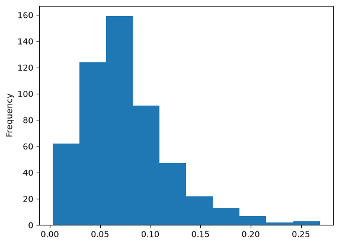

```python
### View normalized data in histogram
occurrence_df.norm_occurrences.plot.hist()
```

```python
occurrence_df['norm_occurrences'].min
```

```
<bound method Series.min of ecoregion  month
17.0       8.0      0.057057
23.0       1.0      0.052764
           2.0      0.159978
           3.0      0.127895
           4.0      0.233931
                      ...
828.0      8.0      0.057057
839.0      5.0      0.033841
           7.0      0.048443
           8.0      0.147677
           9.0      0.031231
Name: norm_occurrences, Length: 530, dtype: float64>
```

### Make an interactive plot

Simplify the geometry to speed up processing

```python
ecoreg_gdf.geometry = ecoreg_gdf.simplify(

    ### can increase the number above 0.05 to 0.1 to speed up
    .05,

    ### set this to false to make it process faster
    preserve_topology=False)

### change the CRS to Mercator for mapping
ecoreg_gdf = ecoreg_gdf.to_crs(ccrs.Mercator())

### check that the plot runs in a reasonable amount of time

ecoreg_gdf.hvplot(geo = True, crs = ccrs.Mercator())
```

Prep the data, then combine the occurrence data with the ecoregions

```python
### rename ecoregID to match occurrence_df
ecoreg_gdf = ecoreg_gdf.rename(columns = {'OBJECTID': 'ecoregion'})

### make ecoreg ID the index for merge with occurrence_df
ecoreg_gdf = ecoreg_gdf.set_index('ecoregion')
ecoreg_gdf.head

### join the occurrences with the plotting GeoDataFrame
occurrence_gdf = ecoreg_gdf.join(occurrence_df)
```

```python
### activate panel and hvplot extensions you'll need for the interactive plot
pn.extension()
hv.extension("bokeh")
```

Make a map with the basemap

```python
### get the plot bounds
xmin, ymin, xmax, ymax = occurrence_gdf.total_bounds

### define the slider widget
slider = pn.widgets.DiscreteSlider(
    name = 'month',
    options = {calendar.month_name[i]: i for i in range(1, 13)}
)

# ## make the basemap tile object
carto_tiles = hv.Tiles(
    ("https://basemaps.cartocdn.com/rastertiles/voyager/{Z}/{X}/{Y}.png"
     "?key=cb1_446c_1_8946b413de0ace50f732dbf1"),
     name = "CARTO"
)

### plot occurrence by ecoregion and month
migration_plot = (
    occurrence_gdf
    .hvplot(

        ### color by number of occurrences
        c = 'norm_occurrences',

        ### group by month
        groupby = 'month',

        ### set up for basemap tiles
        geo = True, crs = ccrs.Mercator(),

        tiles = carto_tiles,

        ### add a title
        title = "Least Sandpiper Migration Based on Normalized Mean Number of Monthly Observations",
        # color='black',

        ### set plot boundaries
        # xlim = (xmin, xmax), ylim = (ymin, ymax),
        # ### Center the map on the Americas which is the primary range of this species
        xlim = (-19000000, -3500000), ylim = (-7500000, 11000000),
        xlabel = 'Longitude',
        ylabel = 'Latitude',

        ### set dimensions of map
        frame_height = 600,
        frame_width = 900,


        ### put the widget at the bottom of the map
        widget_location = 'bottom',
        colorbar = True,
        clabel = 'Normalized Mean Number of Observations',
        ### So that color bar values remain stable across ecoregions and easier to interpret numbers
        ### use max and min of the dataset for more colors
        clim = (0.031, 0.233),
                widgets = {'month': slider}
    )
)
### wrap  plot in the Panel layout
interactive_migration_plot = pn.panel(migration_plot)

### check it out
interactive_migration_plot
```

```
BokehModel(combine_events=True, render_bundle={'docs_json': {'fe2e59bb-e25c-40f5-89d7-c6f571e0dfae': {'version…
```

```python
### make path for the map
map_path_carto = os.path.join(data_dir, "migration_carto_demo_adelia.html")
map_path_carto

### export your map
migration_plot.save(
    map_path_carto,
    embed = True,
    resources = "inline",
)
```

```
WARNING:W-1005 (FIXED_SIZING_MODE): 'fixed' sizing mode requires width and height to be set: figure(id='p83646', ...)
```